# DID - explicación del método

Alejandro Blumenfeld, José Chelquer

# El método de DIferencia en Diferencias (DID)

## Introducción

Diferencia en Diferencias es un método cuasiexperimental usado con frecuencia para evaluar el impacto de un tratamiento o una intervención (p.ej. una política pública) que se implementan en el tiempo y donde no es posible disponer de grupos de control y experimentales adecuados.  
Para mayor claridad en la exposición se trabajará con datos sintetizados sobre un hipotético problema de reducción de las muertes por accidente de tránsito.

## Setup

```r
# Configuración global para gráficos
knitr::opts_chunk$set(
  fig.width = 5,  # Ancho estándar en pulgadas
  fig.height = 3, # Alto estándar en pulgadas
  dpi = 300       # Resolución estándar
)
```

## Librerías

```r
library(dplyr)
library(ggplot2)
library(broom)
library(tibble)
```

## Funciones a usar

### Grupo sintético

La función genera n_unidades de filas u observaciones para cada uno de n_periodos La evolución de la variable de interés (valor) es básicamente lineal aunque pueden agregarse, si se quiere, derivadas de 2do y 3er orden.  
Si hay especificado un periodo_trat, en ese período se produce un salto en el valor (y eventualmente un cambio en alguna derivada) y los datos a partir de allí se marcan con la variable tratamiento=1  
Se puede agregar una lista de shoks: saltos de valor que ocurren en meses específicos.  
Se almacena un nombre para el grupo y un id que sólo es un placeholder, porque se completa según cómo se vaya a usar este grupo (como control o como tratamiento),  
A los datos se agrega ruido según una distribución normal con desvío sd.

```r
# Crea un dataframe de un grupo sintético a partir de parámetros

grupo_sintetico <- function(
    nom_grupo='sin nombre',   # nombre del grupo.
    n_unidades=50,            # cantidad de mediciones
    n_periodos=10,            # cantidad total de periodos

    y0 = 12,                  # ordenada al origen
    vPre = 0,                 # pendiente (velocidad) sin tratamiento
    # para modelar comportamientos no lineales sencillos:
    aPre=0,                   # aceleración pre tratamiento
    d3Pre=0,                  # derivada 3era pre tratamiento
    # para generar ruido
    sd=0.05,                   # desvío estándar de los valores

    periodo_trat=Inf,         # periodo en que se aplica el tratamiento (o Inf si no lo recibe)
    salto = -1,               # salto de valor debido al tratamiento
                              # se produce en el período_trat


    # Si se quiere, se puede modelar que el tratamiento no sólo produzca un salto
    # en la variable de interés sino también un cambio en alguna de sus derivadas

    dcambia=0,              # 1:velocidad, 2:aceleración, 3:derivada tercera
    dnueva=0,                # nuevo valor de la derivada dcambia


    shocks=list()
    #shocks=list(6=10, 9=10   # lista de periodos en que hay un shock externo y su valor
)

{
# creo diccionario con los parámetros usados para crear el grupo, sólo para tenerlo registrado
  dict_grupo = list(
    nom_grupo=nom_grupo,
    n_unidades=n_unidades,
    n_periodos=n_periodos,

    y0=y0,
    vPre=vPre,
    aPre=aPre,
    d3Pre=d3Pre,
    sd=sd,

    periodo_trat=periodo_trat,
    dcambia=dcambia,
    dnueva=dnueva,
    salto=salto,
    shocks=shocks
  )

    dict_grupos[[nom_grupo]]<<- dict_grupo     #almacena el diccionario
    # ---------------------------
    # Creación de grupo sintético
    # ---------------------------
    # Crear un dataframe vacío
    ult_periodo=n_periodos-1
    data <- data.frame(
      # Numeración secuencial
    id = rep(1:n_unidades, times = n_periodos),
     # Repetir el 'grupo' n_unidades * n_periodos veces
    nom_grupo = rep(nom_grupo, times = n_unidades * n_periodos),
     # Repetir los periodos, cada periodo 'n_unidades' veces
    periodo = rep(0:ult_periodo, each = n_unidades),
    valor = NA,
    grupo='0',
    id_grupo=0,
    tratamiento=0
    )

    # Genero los valores base, sin el ruido
    valores_base=numeric(n_periodos)
    tratamientos=numeric(n_periodos)

    # inicializa derivadas
    velocidad=vPre
    aceleracion=aPre
    d3=d3Pre


    for (periodo in seq(0, n_periodos-1)) {     #i: número de período
        if (periodo < periodo_trat) {                #periodos sin tratamiento
          tratamiento=0
           }
        else {                                 #periodos con tratarmiento
          tratamiento=1
          if (dcambia==1) {velocidad=dnueva}
          if (dcambia==2) {aceleracion=dnueva}
          if (dcambia==3) {d3=dnueva}
        }
        delta=0
        if (periodo==periodo_trat){
          delta=salto
        }
        # Shocks
         #busco un schock para el período en cuestión
        shock=shocks[[as.character(periodo)]]
        if (is.numeric(shock)){              # si hay un shock
           # lo sumo al salto que podría haber eventualmente por el tratamiento
          delta=delta+shock}

       # asignar valor calculado
        i=periodo+1  # para no almacenar en subíndice 0
        valores_base[i] <- ifelse(i == 1, y0, valores_base[i - 1] + velocidad + delta)
        tratamientos[i]<-tratamiento

        # recalcular las derivadas
        aceleracion=aceleracion+d3
        velocidad=velocidad+aceleracion

    }

        # Asignar los valores con ruido
      data$valor <- rep(valores_base, each = n_unidades) +
                  rnorm(n_unidades * n_periodos, mean = 0, sd = sd)

      # registrar meses pre y post tratamiento
      data$tratamiento <-rep(tratamientos, each=n_unidades)

      # convertir el grupo en factor
      data$grupo <- as.factor(data$id_grupo)



      return (data)
}
```

### Función de graficacion

Grafica un dataset que contiene 1 o 2 grupos.  
El grupo 1 es el de tratamiento y el 0 el de referencia.  
Se puede elegir el período a graficar, los grupos a mostrar (0, 1 o 1 y 0).  
El gráfico muestra siempre la evolución promedio de ambos grupos.  
Opcionalmente, se puede indicar una cantidad de casos a seguir individualmente.  
Alternativamente, se puede pedir que solo se muestren los puntos sumados al promedio.  
Finalmente, se puede pedir dibuje con línea punteada la evolución supuesta (contrafáctica) del grupo de tratamiento en base al comportamiento del grupo de referencia.

```r
graficar_data <- function(data,                                 # dataframe con los grupos
  desde_periodo = 1,                    # mostrar desde este período
  hasta_periodo = max(data$periodo),    # hasta éste
  grupos = sort(unique(data$grupo)),    # grupos a mostrar. 0: referencia 1: tratamiento
  casos = 0,          # si casos > 0, se sigue la evolución de algunos casos
  puntos = TRUE,      # mostrar los puntos (se usa sólo si casos=0)
  contrafactico=FALSE # dibujar contrafáctico para el tratamiento en base al referencia
)
  {
       # Filtrar por el rango de periodos y los grupos seleccionados
       #  por fecha
  data_filtrada <- data[data$periodo >= desde_periodo & data$periodo <= hasta_periodo, ]
       # por grupos
  data_filtrada <- data_filtrada[data_filtrada$id_grupo %in% grupos, ]

  # si se pide un contrafáctico, se lo construye en base al grupo de referencia (si lo hay...)
  if (contrafactico && (!(0 %in% grupos) | (!(1 %in% grupos)))) {contrafactico <- FALSE}
  if (contrafactico){
    data_filtrada=data_con_contrafacticos(data_filtrada)
  }

     # Si el parámetro casos es mayor que 0, seleccionamos aleatoriamente los casos
 if (casos > 0) {
  data_filtrada <- data_filtrada %>%
    group_by(grupo) %>%
    filter(id %in% sample(unique(id), size = min(casos, n_distinct(id)))) %>%
    ungroup()  # Aseguramos que el grupo quede desagrupado
 }
  # Iniciar el gráfico
  p <- ggplot(data_filtrada, aes(x = periodo, y = valor, color = grupo)) +
                              # punteada para el contrafactico
        scale_linetype_manual(values = c("solid", "solid", "dashed")) +
    labs(title = paste("Evolución desde período ", desde_periodo, "hasta", hasta_periodo),
         x = "periodo",
         y = "Resultado (valor)",
         color = "Grupo") +  # Etiqueta para la leyenda

    guides(linetype = "none")+  # Desactiva la leyenda para linetype
    scale_color_manual(values = c(`0` = "blue", `1` = "red", `2` = "lightcoral"),
                       labels = c(`0` = "referencia", `1` = "Tratamiento", '2' = "Contrafáctico")) +  # Etiquetas para la leyenda

    scale_x_continuous(breaks = seq(min(data_filtrada$periodo), max(data_filtrada$periodo), by = 1)) +  # periodos enteros

    theme_minimal() +

    theme(legend.position = "top")  # Posicionar la leyenda en la parte superior

   # Si puntos es TRUE, agregar los puntos al gráfico

  # Si casos > 0, agregar las líneas para la evolución de cada id
  if (casos > 0) {
       p <- p + geom_line(aes(group = interaction(grupo, id)),
                     alpha = 0.8)    # Línea de evolución para cada elemento (id) dentro de su grupo
  }
  else {
    if (puntos) {
           #los puntos sólo se muestran si no se analiza caso por caso
         p <- p + geom_jitter(alpha = 0.5, width = 0.2)  # Puntos dispersos
    }
  }

  # Agregar la línea de promedio por grupo (siempre)
  p <- p +
  stat_summary(fun = mean, geom = "line", aes(group = grupo, linetype=grupo),
               linewidth = 1.5) +
    # Línea punteada para el contrafáctico
  guides(linetype = "none")  # Desactiva la leyenda para linetype



  # Mostrar el gráfico
  print(p)
}

data_con_contrafacticos=function (data) {
  #Agrega a data registros contrafácticos para el grupo 1 en base a las diferencias
  # que tenía con el grupo 0 en el mes previo al tratamiento

  # Identificar el último período con tratamiento = 0 para id_grupo = 1
  ultimo_periodo <- data %>%
    filter(id_grupo == 1, tratamiento == 0) %>%
    summarise(ultimo_periodo = max(periodo)) %>%
    pull(ultimo_periodo)
  # Calcular promedios por grupo en el último período
  promedios <- data %>%
    filter(periodo == ultimo_periodo) %>%
    group_by(id_grupo) %>%
    summarise(promedio_valor = mean(valor, na.rm = TRUE))
    # Extraer los promedios de los grupos
  promedio_grupo0 <- promedios %>% filter(id_grupo == 0) %>% pull(promedio_valor)
  promedio_grupo1 <- promedios %>% filter(id_grupo == 1) %>% pull(promedio_valor)

  # Calcular la diferencia
  diferencia_promedios <- promedio_grupo1 - promedio_grupo0

  # Filtrar registros de id_grupo = 0 con periodo > último periodo y convertirlos en contrafácticos
  nuevos_registros <- data %>%
    filter(id_grupo == 0, periodo >= ultimo_periodo) %>%
    mutate(
      id_grupo = 2,  # Cambiar id_grupo a 2
      grupo= as.factor(2),
      nom_grupo=paste0(nom_grupo,"_cfactico"),
      tratamiento=0,
      valor = valor + diferencia_promedios  # Ajustar el valor con la diferencia
    )

  # Agregar los nuevos registros al dataset original
  data <- bind_rows(data, nuevos_registros)
  return(data)


}
```

### Obtener periodo de tratamiento de los datos

Dado un dataset, permite deducir en qué período se aplicó el tratamiento.

```r
periodo_tratamiento=function(data){
  # obtiene el período de tratamiento fijándose en el grupo 1 (de tratamiento)
  # el mes en que empieza a tener tratamiento=1

  grupo1 <- subset(data, id_grupo == 1)
  # Encontrar el mínimo periodo donde tratamiento = 1
  periodo_trat <- min(grupo1$periodo[grupo1$tratamiento == 1])
  return (periodo_trat)

}
```

### Seleccionar grupos

Arma un dataset (para graficar, para hacer regresión etc) con un grupo de tratamiento y uno de referencia.

```r
seleccionar_grupos=function(
    grupo1=data.frame(),           # grupo de tratamiento
    grupo2=data.frame())           # grupo de referencia
  {
 # junta dos grupos. El primero pasa a ser el de tratamiento (1) y el 2do el de referencia (0)
 return (
   rbind(
    grupo1 %>% mutate(id_grupo=1) %>% mutate(grupo=as.factor(1)),
    grupo2 %>% mutate(id_grupo=0) %>% mutate(grupo=as.factor(0))
  )
 )
}
```

## Armar grupos

### Grupos para referencia:

parejoConShock Sin tratamiento. Schock en mes_trat comparable a un salto de intervencion. parejoSinShock Sin tratamiento. Valor estable. subiendoSinShock Con pendiente 0.5 curvaSinShock Cúbico, con velocidad inicial 0, aceleración 0.8 y der 3era=-0,3

### Grupos para Tratamiento

Todos los siguientes grupos tienen tratamiento en periodo_trat, con el consiguiente salto. parejoConTratamiento Estable. subiendoConTratamiento Con pendiente 0.5 curvaConTratamiento Similar a la curvaSinSchok, pero con tratamiento bajandoConstante Con un salto menor y un punto a arranque y pendiente que disimulen el efecto del tratamiento

```r
dict_grupos=list()           # inicializa diccionario de grupos

set.seed(123) # Para reproducibilidad
# valores base
n_unidades=50          # cantidad de mediciones
n_periodos=8             # cantidad total de periodos
                         # pre tratamiento
y0 = 11.94               # ordenada al origen base
vPre =0                  # pendiente sin tratamiento
aPre = 0                 # aceleración
d3Pre=0                  # derivada
                         # cambios por el tratamiento
dcambia=0                # derivada que cambia con el tratamiento
dnueva= 0                # nuevo valor de la derivada que cambia
salto = 11.14-11.94+.3
# salto de valor debido al tratamiento entre periodo m_trat y el siguiente
sd=0.2                      # desvío estándar de los valores
periodo_trat=5               # periodo del tratamiento (o Inf si no lo recibe)
dif1=-0.8

#referencia
parejoConShock= grupo_sintetico(
      nom_grupo='parejoConShock',
      n_unidades=n_unidades,
      n_periodos=n_periodos,
      y0 = y0+dif1,
      shocks=list(
        '5'=salto)
  )
parejoSinShock=grupo_sintetico(
      nom_grupo='parejoSinShock',
      n_unidades=n_unidades,
      n_periodos=n_periodos,
      y0 = y0+dif1,
  )
subiendoSinShock=grupo_sintetico(
      nom_grupo='subiendoSinShock',
      n_unidades=n_unidades,
      n_periodos=n_periodos,
      y0 = y0+dif1,
      vPre=0.5
  )
curvaSinShock=grupo_sintetico(
      nom_grupo='curvaSinShock',
      n_unidades=n_unidades,
      n_periodos=n_periodos,
      y0 = y0+dif1,
      vPre=0,
      aPre=0.8,
      d3Pre=-0.3
)


# Tratamiento
parejoConTratamiento= grupo_sintetico(
      nom_grupo='parejoConTratamiento',
      n_unidades=n_unidades,
      n_periodos=n_periodos,
      y0 = y0,
      periodo_trat=periodo_trat,
      salto = salto,
 )
subiendoConTratamiento = grupo_sintetico(
      nom_grupo='subiendoConTratamiento',
      n_unidades=n_unidades,
      n_periodos=n_periodos,
      y0 = y0,
      vPre=0.5,
      periodo_trat=periodo_trat,
      salto = salto,
  )

curvaConTratamiento = grupo_sintetico(
      nom_grupo='curvaConTratamiento',
      n_unidades=n_unidades,
      n_periodos=n_periodos,
      y0 = y0,
      vPre=0,
      aPre=0.8,
      d3Pre=-0.3,

      periodo_trat=periodo_trat,
      salto = salto,
  )

bajandoConstante=grupo_sintetico(
      nom_grupo='bajandoConstante',
      n_unidades=n_unidades,
      n_periodos=n_periodos,
      y0 = y0+dif1-(salto/1.1)*mes_trat,
      vPre=salto/1.1,
      salto=salto/3,
      periodo_tra=periodo_trat
 )
```

# El efecto de una intervención

Los accidentes de tránsito son la principal causa de muerte entre jóvenes de 18 a 35 y afecta seriamente a las demás franjas de población.  
Se calcula que, a nivel nacional, la tasa de víctimas fatales es de alrededor de 9 cada 100.000 habitantes.  
La de Salta, la más alta del país, es de 11.94.  
Hasta aquí, datos reales. Ahora empezamos a imaginar escenarios.  
Salta decide aumentar severamente las multas por infracciones de tránsito en la esperanza de que esto tenga impacto en la siniestralidad. Vamos a ubicar estos evento en una escala temporal arbitraria que empieza en el período 1, y suponemos que la medida de Salta entra en vigor en el período 5.<BR

Las autoridades quieren evaluar el impacto de esta intervención.

### Dos grupos estables, uno con tratamiento y el otro con shock

#### Efecto inmediato presunto del tratamiento

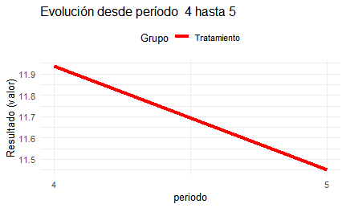

```r
data=seleccionar_grupos( parejoConTratamiento, parejoConShock)
graficar_data(data,
              desde_periodo=periodo_trat-1,
              hasta_periodo= periodo_trat,
              grupos=c(1),
              casos=0,
              puntos=FALSE
)
```

Hubo efectivamente un descenso de las víctimas fatales.  
Los críticos sostienen que no basta con ver este resultado, porque quizás la siniestralidad ya venía descendiendo sin la intervención del gobierno.

#### Posible historia previa

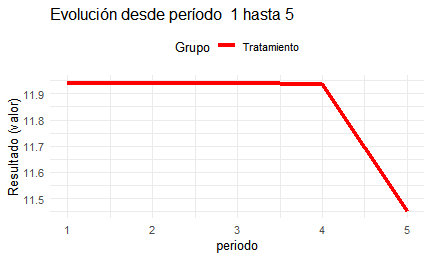

```r
graficar_data(data,
              desde_periodo=periodo_trat-4,
              hasta_periodo= periodo_trat,
              grupos=c(1),
              puntos=FALSE,
              casos=0
)
```

Un examen de la historia previa sugiere que no es éste el caso: la baja no es resultado de una tendencia previa.

###@ Una historia previa diferente Distinto hubiese sido el caso si al examinar la evolución previa viéramos lo siguiente:

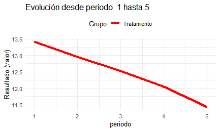

```r
data=seleccionar_grupos( bajandoConstante)

graficar_data(data,
              desde_periodo=periodo_trat-4,
              hasta_periodo= periodo_trat,
              grupos=c(1),
              puntos=FALSE,
              contrafactico=TRUE
)
```

Las críticas continúan y señalan que en el período en cuestión hubo un aumento importante del precio de las naftas que podría haber reducido el tránsito y la siniestralidad.  
Tucumán es una provincia vecina y similar a Salta. ¿Qué pasó con ella?

#### Comparación con grupo de referencia

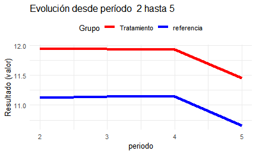

```r
data=seleccionar_grupos( parejoConTratamiento, parejoConShock)
graficar_data(data,
              desde_periodo=periodo_trat-3,
              hasta_periodo= periodo_trat,
              grupos=c(0, 1),
              puntos=FALSE
)
```

Tucumán tiene un nivel de siniestralidad menor, pero un comportamiento comparable al de Salta: hasta el período de la intervención las muertes en accidentes se mantenían aproximadamente constantes y en ese período bajaron en forma similar. Pero en Tucumán no se legisló el cambio de multas…  
Aparentemente, el descenso de la siniestralidad en Salta fue parte de un proceso que afectó a otras provincias similares donde el tratamiento no se aplicó.

#### Mismo caso pero con referencia sin Shock

Distinta sería la situación en un caso como este:

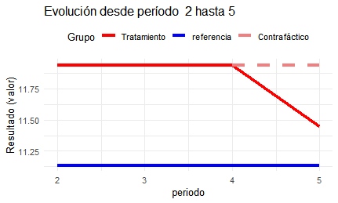

```r
data=seleccionar_grupos( parejoConTratamiento, parejoSinShock)

graficar_data(data,
              desde_periodo=periodo_trat-3,
              hasta_periodo= periodo_trat,
              grupos=c(0, 1),
              puntos=FALSE,
              contrafactico=TRUE
)
```

Las líneas punteadas muestran lo que, presuntamente, hubiese ocurrido con el grupo de interés si no se le hubiese aplicado el tratamiento.  
En este caso, ambos grupos venían evolucionando en forma paralela pero en el período de tratamiento, el grupo de tratamiento redujo su tasa de víctimas en tanto el de referencia la mantuvo.  
Dada la evolución paralela de ambos grupos, se supone que el grupo de tratamiento, si no lo hubiese recibido, hubiese evolucionado en forma similar al del referencia.< Se trata de un razonamiento contrafáctico y la evolució en cuestión es la que se muestra en color más claro y con línea punteada.  
### Evoluciones previas lineales o no lineales  
La situación sería similar aunque hubiese alguna evolución en el período previo al tratamiento:

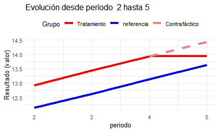

```r
data=seleccionar_grupos( subiendoConTratamiento, subiendoSinShock)

graficar_data(data,
              desde_periodo=periodo_trat-3,
              hasta_periodo= periodo_trat,
              grupos=c(0, 1),
              puntos=FALSE,
              contrafactico=TRUE
)
```

De hecho, las historias previas de ambos grupos podrían ser paralelas y con otras formas.

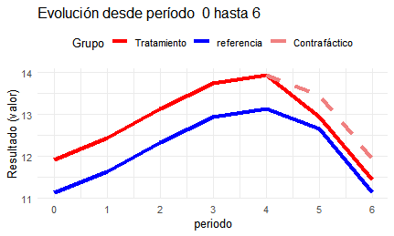

```r
data=seleccionar_grupos( curvaConTratamiento, curvaSinShock)

graficar_data(data,
              desde_periodo=periodo_trat-5,
              hasta_periodo= periodo_trat+1,
              grupos=c(0, 1),
              puntos=FALSE,
              contrafactico=TRUE
)
```

# DID: diferencias en diferencias

La idea del método de diferencias en diferencias es sencilla.

El supuesto básico es que los dos grupos vienen evolucionando en forma paralela, de modo que las diferencias entre ellos son constantes.  
Se calcula esta diferencia: llamémosla diferencia_pre.  
Se calcula la diferencia post tratamiento entre ambos. Llamémosla diferencia_post  
Se supone entonces que la verdadera diferencia provocada por la intervención es la diferencia entre ellas: diferencia_post-diferencia_pre. De ahí el nombre de diferencia en diferencias.  
Existe, sin embargo, un segundo supuesto, y es que ambos grupos estuvieron sometidos, durante el período de tratamiento, a los mismos shocks, de modo que pueda concluirse los cambios en la distancia entre ambos (la DID) se explique por la intervención y no por otra causa.

## Diferencias por lm

Esta función toma dos grupos (uno de tratamiento y uno de referencia), los grafica y hace la regresión correspondiente.  
Si mod=‘basico’ trabaja sólo con el mes previo a la intervención y el de la intervención misma.  
Si no, trabaja con toda la historia (previa y posterior) disponible.

```r
diferencias_lm <- function (
    grupo1,       # grupo de tratamiento
    grupo0,       # grupo de referencia
    mod ='basico',  # basico: sólo los meses pre y post tratamiento
                     # periodos: por períodos
                     # no_paralelos: con variable periodo*grupo
    decimales=-1     #
    )
  {
  data=seleccionar_grupos(grupo1, grupo0)
  periodo_trat=periodo_tratamiento(data)
  data$post_trat <- ifelse(data$periodo >= periodo_trat, 1, 0)  #periodos post tratamiento
  if (mod=='basico'){
    data <- data %>%
         filter(periodo %in% c(periodo_trat - 1, periodo_trat))
  }

  graficar_data(data,
              desde_periodo=periodo_trat-3,
              hasta_periodo= periodo_trat+1,
              grupos=c(0, 1),
              casos=10,
              puntos=TRUE,
              contrafactico=FALSE
)

  # Crear variables de tratamiento y periodo
  data <- data %>%
          # Indicador de que el período es post tratamiento
    mutate(post_tratamiento = ifelse(periodo >= periodo_trat, 1, 0),
           # Indicador de que se aplicó el tratamiento
           did = id_grupo * post_tratamiento,  # Interacción
           # Indicador de si es el grupo de tratamiento
           grupo_trat = id_grupo
    )

  # Ajustar el modelo de regresión
  modelo_basico <- lm(valor ~ grupo_trat + post_trat + did, data = data)
  modelo_periodos <- lm(valor ~ grupo_trat + periodo + did, data = data)

  data$fx <- factor(data$grupo_trat, levels = c(0, 1), labels = c("Ref", "Tr"))

  modelo_no_paralelos <- lm(valor ~grupo_trat + periodo:fx + did, data=data)

  if (mod=='basico'){modelo_did=modelo_basico}
  else {
    if (mod=='periodos') {modelo_did=modelo_periodos}
      else  { modelo_did=modelo_no_paralelos}
  }



  # Resumen del modelo
  print (glance(modelo_did))
  tidy_resultado=tidy(modelo_did, conf.int=TRUE)
  # Limitar la cantidad de decimales a 2
  if (decimales>0) {
  tidy_resultado <- tidy_resultado %>%
    mutate(across(where(is.numeric), ~ round(.x, decimales)))
  }
  tidy_traspuesto <- as.data.frame(t(column_to_rownames(tidy_resultado, var = "term")))
  tidy_traspuesto


}
```

### parejo vs parejo sin shock

En este caso, ambos grupos son estables salvo por el impacto del tratamiento en el grupo pertinente.

| r.squared | adj.r.squared | sigma | statistic | p.value | df | logLik | AIC | BIC | deviance | df.residual | nobs |
| --- | --- | --- | --- | --- | --- | --- | --- | --- | --- | --- | --- |
| 0.9762391 | 0.9758755 | 0.0518775 | 2684.287 | 7.569086e-159 | 3 | 310.0066 | -610.0131 | -593.5216 | 0.52749 | 196 | 200 |

|  | (Intercept) | grupo_trat | post_trat | did |
| --- | --- | --- | --- | --- |
| estimate | 1.113186e+01 | 8.053436e-01 | 0.001316049 | -4.892044e-01 |
| std.error | 7.336587e-03 | 1.037550e-02 | 0.010375501 | 1.467317e-02 |
| statistic | 1.517308e+03 | 7.761973e+01 | 0.126841935 | -3.334005e+01 |
| p.value | 0.000000e+00 | 4.037808e-149 | 0.899195534 | 1.042380e-82 |
| conf.low | 1.111739e+01 | 7.848816e-01 | -0.019145904 | -5.181419e-01 |
| conf.high | 1.114633e+01 | 8.258055e-01 | 0.021778001 | -4.602668e-01 |

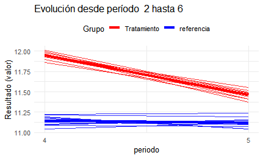

```r
diferencias_lm( parejoConTratamiento, parejoSinShock, mod='basico')
```

### parejo vs parejo con shock

En este caso, ambos grupos son estables salvo por el impacto del tratamiento en el grupo pertinente y por un shock que afecta a ambos grupos en el mismo período de tratamiento.  
En este caso, el modelo usado es básico (sólo 2 períodos)

| r.squared | adj.r.squared | sigma | statistic | p.value | df | logLik | AIC | BIC | deviance | df.residual | nobs |
| --- | --- | --- | --- | --- | --- | --- | --- | --- | --- | --- | --- |
| 0.9890137 | 0.9888455 | 0.04974482 | 5881.456 | 1.124271e-191 | 3 | 318.4023 | -626.8047 | -610.3131 | 0.4850113 | 196 | 200 |

|  | (Intercept) | grupo_trat | post_trat | did |
| --- | --- | --- | --- | --- |
| estimate | 1.113957e+01 | 7.976294e-01 | -4.871014e-01 | -0.0007868758 |
| std.error | 7.034981e-03 | 9.948965e-03 | 9.948965e-03 | 0.0140699611 |
| statistic | 1.583455e+03 | 8.017210e+01 | -4.896001e+01 | -0.0559259415 |
| p.value | 0.000000e+00 | 8.626014e-152 | 7.231632e-112 | 0.9554577734 |
| conf.low | 1.112570e+01 | 7.780086e-01 | -5.067222e-01 | -0.0285348261 |
| conf.high | 1.115345e+01 | 8.172502e-01 | -4.674807e-01 | 0.0269610745 |

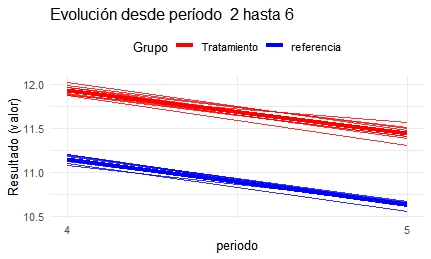

```r
diferencias_lm( parejoConTratamiento, parejoConShock, mod='basico')
```

### parejo vs parejo con shock

Con los mismos datos que el anterior, pero usando el modelo de períodos, donde se supone que hay una evolución lineal de base.

| r.squared | adj.r.squared | sigma | statistic | p.value | df | logLik | AIC | BIC | deviance | df.residual | nobs |
| --- | --- | --- | --- | --- | --- | --- | --- | --- | --- | --- | --- |
| 0.9323631 | 0.9321082 | 0.1226489 | 3657.573 | 0 | 3 | 545.5977 | -1081.195 | -1057.772 | 11.97403 | 796 | 800 |

|  | (Intercept) | grupo_trat | periodo | did |
| --- | --- | --- | --- | --- |
| estimate | 1.119808e+01 | 0.88361522 | -6.992564e-02 | -2.166052e-01 |
| std.error | 1.028866e-02 | 0.01050303 | 2.360379e-03 | 1.579868e-02 |
| statistic | 1.088391e+03 | 84.12959105 | -2.962475e+01 | -1.371034e+01 |
| p.value | 0.000000e+00 | 0.00000000 | 1.375351e-130 | 1.460676e-38 |
| conf.low | 1.117788e+01 | 0.86299832 | -7.455895e-02 | -2.476172e-01 |
| conf.high | 1.121827e+01 | 0.90423212 | -6.529234e-02 | -1.855932e-01 |

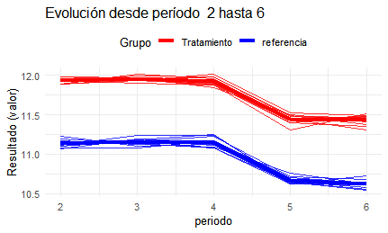

```r
diferencias_lm( parejoConTratamiento, parejoConShock, mod='periodos')
```

### subiendo vs subiendo sin shock

El modelo básico de 2 meses aplicado a dos casos con tendencia previa ascendente.

| r.squared | adj.r.squared | sigma | statistic | p.value | df | logLik | AIC | BIC | deviance | df.residual | nobs |
| --- | --- | --- | --- | --- | --- | --- | --- | --- | --- | --- | --- |
| 0.9774193 | 0.9770737 | 0.0493246 | 2827.996 | 5.140919e-161 | 3 | 320.099 | -630.1981 | -613.7065 | 0.4768516 | 196 | 200 |

|  | (Intercept) | grupo_trat | post_trat | did |
| --- | --- | --- | --- | --- |
| estimate | 1.314856e+01 | 7.915259e-01 | 4.948644e-01 | -5.054334e-01 |
| std.error | 6.975552e-03 | 9.864920e-03 | 9.864920e-03 | 1.395110e-02 |
| statistic | 1.884950e+03 | 8.023642e+01 | 5.016406e+01 | -3.622892e+01 |
| p.value | 0.000000e+00 | 7.405403e-152 | 8.775819e-114 | 8.468861e-89 |
| conf.low | 1.313481e+01 | 7.720709e-01 | 4.754094e-01 | -5.329470e-01 |
| conf.high | 1.316232e+01 | 8.109809e-01 | 5.143194e-01 | -4.779199e-01 |

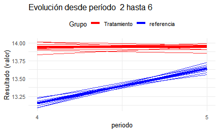

```r
diferencias_lm( subiendoConTratamiento, subiendoSinShock, mod='basico')
```

## subiendo vs parejo sin shock

El modelo períodos aplicado a dos casos con tendencia previa diferente.  
La falta de paralelismo previo afecta los resultados

| r.squared | adj.r.squared | sigma | statistic | p.value | df | logLik | AIC | BIC | deviance | df.residual | nobs |
| --- | --- | --- | --- | --- | --- | --- | --- | --- | --- | --- | --- |
| 0.9190511 | 0.9187461 | 0.3876799 | 3012.456 | 0 | 3 | -375.0855 | 760.171 | 783.5941 | 119.6354 | 796 | 800 |

|  | (Intercept) | grupo_trat | periodo | did |
| --- | --- | --- | --- | --- |
| estimate | 10.75032833 | 1.961853e+00 | 1.114054e-01 | 1.058328e+00 |
| std.error | 0.03252132 | 3.319892e-02 | 7.460902e-03 | 4.993791e-02 |
| statistic | 330.56249082 | 5.909388e+01 | 1.493189e+01 | 2.119287e+01 |
| p.value | 0.00000000 | 2.620128e-293 | 1.247385e-44 | 2.181013e-79 |
| conf.low | 10.68649065 | 1.896685e+00 | 9.676004e-02 | 9.603023e-01 |
| conf.high | 10.81416601 | 2.027021e+00 | 1.260508e-01 | 1.156353e+00 |

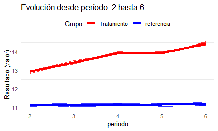

```r
diferencias_lm( subiendoConTratamiento, parejoSinShock, mod='periodos')
```

En cambio, si se incluye el termino de grupo_trat*periodo

| r.squared | adj.r.squared | sigma | statistic | p.value | df | logLik | AIC | BIC | deviance | df.residual | nobs |
| --- | --- | --- | --- | --- | --- | --- | --- | --- | --- | --- | --- |
| 0.997317 | 0.9973035 | 0.05220001 | 73877.93 | 0 | 4 | 1229.495 | -2446.99 | -2418.883 | 2.166248 | 795 | 800 |

|  | (Intercept) | grupo_trat | did | periodo:fxRef | periodo:fxTr |
| --- | --- | --- | --- | --- | --- |
| estimate | 11.14 | 0.80 | -0.49 | 0.50 | 0.00 |
| std.error | 0.00 | 0.01 | 0.01 | 0.00 | 0.00 |
| statistic | 2338.66 | 111.45 | -48.37 | 438.45 | -1.00 |
| p.value | 0.00 | 0.00 | 0.00 | 0.00 | 0.32 |
| conf.low | 11.13 | 0.79 | -0.51 | 0.50 | -0.01 |
| conf.high | 11.15 | 0.82 | -0.47 | 0.50 | 0.00 |

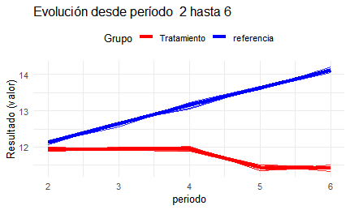

```r
diferencias_lm( parejoConTratamiento, subiendoSinShock, mod='no_paralelos', decimales=2)
```